# TLimmuno2 outperforms existing methods in peptide-MHC II immunogenicity prediction

This part focuses on another independent dataset to compare the performance of TLimmuno2. it contains the following sections:

- Benchmark in immunoigenicity
- Structure immportance
- Neoepitope and wildtype peptide
- Position importance

## Benchmark in immunoigenicity

The IEDB-Benchmark dataset is from the same database as the training set, thus they may have similar distribution patterns, which may lead to systematic bias. To perform an unbiased performance evaluation in predicting immunogenic peptides, we retrieved published papers to collect neoepitopes that were tested experimentally for CD4+ T cell immunogenicity.

### Data proprecessing

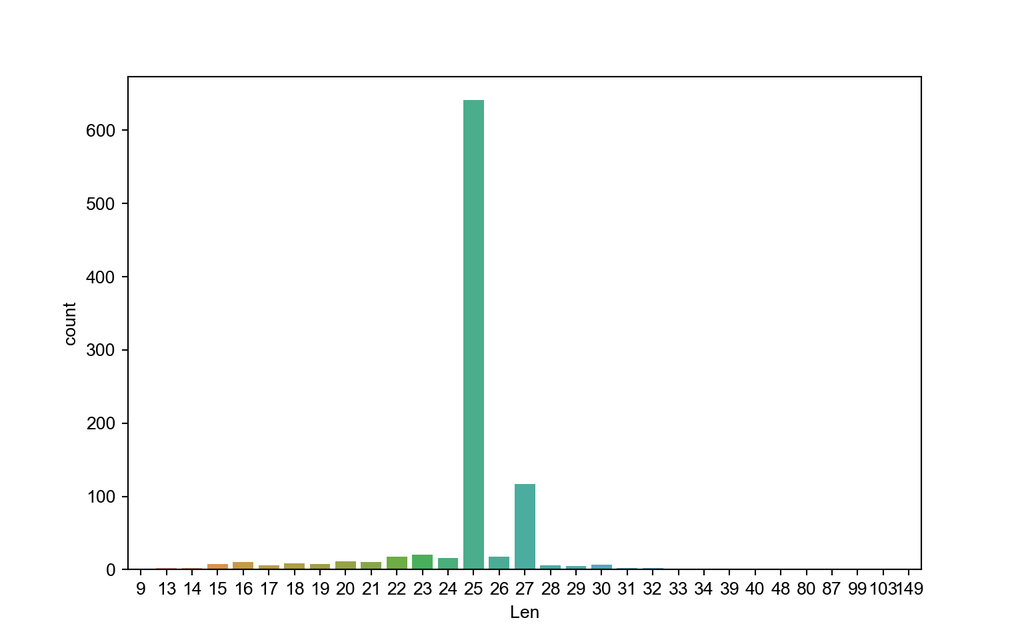

```python
#python
peptide = pd.read_csv("../data/nature_peptide.csv")
HLA = pd.read_csv("../data/nature_HLA.csv")
peptide = peptide.drop_duplicates()
peptide["Immunogenicity"].value_counts()
#> 0    849
#> 1     80
#> Name: Immunogenicity, dtype: int64
peptide["Len"] = peptide["Peptide"].map(len)
peptide[peptide["Len"]>=15]["Peptide"].to_csv("../data/pep_only.txt",header = None,index = None,sep = " ")#chain indexing
IEDB_pep = peptide[peptide["Len"]>=15].reset_index(drop = True)
IEDB_pep["num"] = [x+1 for x in range(len(IEDB_pep))]#used to predict by IEDB tools
pep_ID = ["Pep{}".format(x+1) for x in range(len(peptide))]
peptide["pep_ID"] = pep_ID
fig,ax = plt.subplots()
sns.countplot(data = peptide,x = "Len")
plt.show()
```

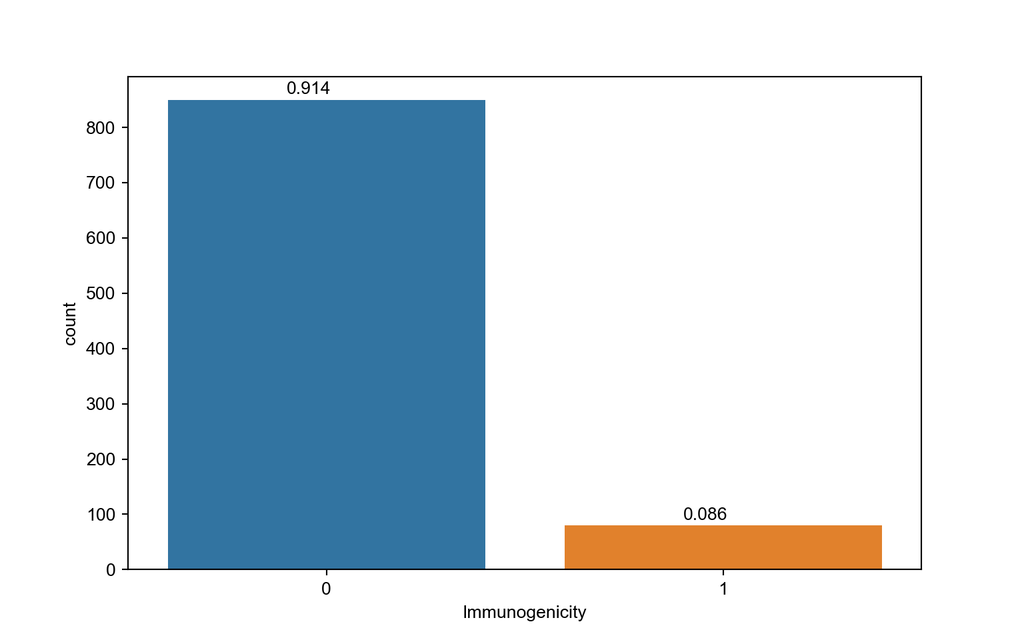

```python
#python
ax = sns.countplot(data=peptide, x="Immunogenicity")
#ax.bar_label(ax.containers[0])
ax.text(-0.1, 860, "{:.3f}".format(851/931))
ax.text(0.9, 90, "{:.3f}".format(80/931))
plt.savefig("../figure/nature_immuno_rate.pdf",dpi = 300,transparent=True)
plt.show()
```

Neoepitopes tested experimentally were usually sequences of 20–25 amino acids, so we use 15-mer and k-mer methods (Methods) to assign a rank value to a given neoepitope.

```python
#python
Data = pd.merge(HLA,peptide)
IMM_train_data_allele = pd.read_csv("../data/IEDB_MHCII_immuno_allele.csv",header = None,names = ["HLA"])
Data = Data[Data["HLA"].isin(IMM_train_data_allele["HLA"])]
pseudo_seq = pd.read_table("../data/pseudosequence.2016.all.X.dat",header = None,names = ["HLA","sequence"])
Data1 = pd.merge(Data,pseudo_seq)
Data1["length"] = Data1["Peptide"].map(len)
Data1 = Data1[Data1["length"]>=13]
Data1 = Data1.reset_index(drop = True)
#15mer
def mer15(Pep):
    P = []
    Length = 15
    for i in range(len(Pep) - Length +1):
        pep = Pep[i:i+Length]
        P.append(pep)
    return P
DF15 = pd.DataFrame()
for i in range(len(Data1)):
    pep = mer15(Data1["Peptide"][i])
    df = pd.DataFrame(pep)
    df["pep_ID"] = Data1["pep_ID"][i]
    df["HLA"] = Data1["HLA"][i]
    DF15 = pd.concat([DF15,df])
DF15.columns = ["pep","pep_ID","HLA"]
benchmark_data = pd.merge(DF15,pseudo_seq)
benchmark_data.to_csv("../data/15mer_data.csv")
benchmark_data["pep"].to_csv("../data/15mer_pep_only.txt",header = None,index = None,sep = " ")
#kmer
def kmer(Pep,sa,end):
    P = []
    R = range(sa,end+1)
    for i in R:
        Length = i
        for i in range(len(Pep) - Length +1):
            pep = Pep[i:i+Length]
            P.append(pep)
    return P
DF_k = pd.DataFrame()
for i in range(len(Data1)):
    pep = kmer(Data1["Peptide"][i],13,21)
    df = pd.DataFrame(pep)
    df["pep_ID"] = Data1["pep_ID"][i]
    df["HLA"] = Data1["HLA"][i]
    DF_k = pd.concat([DF_k,df])
DF_k.columns = ["pep","pep_ID","HLA"]
benchmark_data = pd.merge(DF_k,pseudo_seq)
benchmark_data.to_csv("../data/kmer_data.csv")
```

### Different tools

We also compared the performance of TLimmuno2 with other immunogenicity prediction tools, including IEDB tool (CD4episcore) and Repitope. Note some published methods, such as Deepitope and FIONA do not have the tools publicly available, and are thus not included in the subsequent comparison analysis. we can’t link their website for FIONA and we can’t find the Github repositories for Deepitope.

#### IEDB online tool(CD4episcore)

We run IEDB in their website [IEDB online tool](http://tools.iedb.org/CD4episcore/), and this tool only support 15mer peptides.

#### Repitope

You can find the Repitope in their Github, This tool is very slow and potentially problematic on larger datasets, so we only used 15mer peptides.

```r
#PBS
#R
library(tidyverse)
library(data.table)
library(Repitope)
options(java.parameters="-Xmx60G")

fragLibDT <- fst::read_fst("~/Project/MHCII/Repitope/FragmentLibrary_TCRSet_Public_RepitopeV3.fst", as.data.table=T)
featureDF_MHCII <- fst::read_fst("~/Project/MHCII/Repitope/FeatureDF_MHCII_Weighted.10000_RepitopeV3.fst", as.data.table=T)

data <- read_csv("~/Project/MHCII/Repitope/15mer_data.csv")
peptideSet_of_interest <- data$pep
peptideSet=peptideSet_of_interest
len = sapply(data$pep, nchar)
table(len)

res_MHCII <- EpitopePrioritization(
  featureDF=featureDF_MHCII[Peptide%in%MHCII_Human$Peptide,],
  metadataDF=MHCII_Human[,.(Peptide,Immunogenicity)],
  peptideSet=peptideSet_of_interest,
  peptideLengthSet=11:30,
  fragLib=fragLibDT,
  aaIndexIDSet="all",
  fragLenSet=3:11,
  fragDepth=10000,
  fragLibType="Weighted",
  featureSet=MHCII_Human_MinimumFeatureSet,
  seedSet=1:1,
  coreN=1,
  outDir="~/Project/MHCII/Repitope/pre_result"  ## Intermediate and final output files will be stored under this directory
)
```

#### netMHCIIpan BA&EL

This part code is similar to the IEDB-benchmark dataset, only change the input and output file, so we don’t add code in this part.

#### TLimmuno2

This part code is similar to the IEDB-benchmark dataset, only change the input and output file, so we don’t add code in this part.

### Result

```python
#python
def IMM_process(Data,peptide):
    sam_pep_ID = Data["pep_ID"].unique()
    res = []
    p_ID = []
    Data["length"] = Data["pep"].map(len)
    for a in sam_pep_ID:
        Mean = []
        ID = Data[Data["pep_ID"] == a]
        for i in ID["HLA"].unique():
            Data_HLA = ID[ID["HLA"] == i]
            prediction = []
            for l in Data_HLA["length"].unique():
                Data_len = Data_HLA[Data_HLA["length"] == l]
                pre = Data_len["prediction"].max()
                prediction.append(pre)
            x = np.max(prediction)
            Mean.append(x)
        res.append(max(Mean))
        p_ID.append(a)
    result = pd.DataFrame({"pep_ID":p_ID,"prediction":res})
    result = result.merge(peptide,how = "inner",on = "pep_ID" )
    return result

def auc_pr(data,true_label,prediction,rank = False):
    if rank:
        fpr,tpr,_ = roc_curve(data[true_label],1-data[prediction])
        precision,recall,_ = precision_recall_curve(data[true_label],1-data[prediction])
    else:
        fpr,tpr,_ = roc_curve(data[true_label],data[prediction])
        precision,recall,_ = precision_recall_curve(data[true_label],data[prediction])

    AUC = auc(fpr,tpr)
    PR = auc(recall,precision)

    return fpr,tpr,recall,precision,AUC,PR
```

```python
result = pd.read_csv("../data/15mer_result.csv")
result_15mer = IMM_process(result,peptide)
mer15_result = auc_pr(result_15mer,"Immunogenicity","prediction")
print("AUC:{}".format(mer15_result[4]))
#> AUC:0.7332489451476794
print("PR_AUC:{}".format(mer15_result[5]))
#> PR_AUC:0.198391863815141
```

```python
#python
result = pd.read_csv("../data/kmer_result.csv")
result_kmer = IMM_process(result,peptide)
result_kmer = result_kmer[result_kmer["pep_ID"].isin(result_15mer["pep_ID"])]
kmer_result = auc_pr(result_kmer,"Immunogenicity","prediction")
print("AUC:{}".format(kmer_result[4]))
#> AUC:0.7392635212888378
print("PR_AUC:{}".format(kmer_result[5]))
#> PR_AUC:0.20210218456922854
```

```python
#python
IEDB_res = pd.read_csv("../data/IEDB_CD4_tools_manually.csv")
Imm_score = []
pro_num = []
for i in IEDB_res["Protein Number"].unique():
    y = IEDB_res[IEDB_res["Protein Number"] == i]
    imm_score = y["Immunogenicity Score"].mean()
    pro_num.append(i)
    Imm_score.append(imm_score)
IEDB_result = pd.DataFrame({"num":pro_num,"score":Imm_score})
IEDB_result = pd.merge(IEDB_result,IEDB_pep)
IEDB_result = IEDB_result[IEDB_result["Peptide"].isin(result_15mer["Peptide"])]
IEDB_score = auc_pr(IEDB_result,"Immunogenicity","score",rank = True)
print("AUC:{}".format(IEDB_score[4]))
#> AUC:0.608331415420023
print("PR_AUC:{}".format(IEDB_score[5]))
#> PR_AUC:0.13176952789635926
```

```python
#python
Repitope_result = pd.read_csv("../data/repitope_15mer_result.csv")
Repitope = pd.merge(Repitope_result,DF15,left_on = "Peptide",right_on = "pep")
sam_pep_ID = Repitope["pep_ID"].unique()
res = []
p_ID = []
for a in sam_pep_ID:
    Mean = []
    ID = Repitope[Repitope["pep_ID"] == a]
    for i in ID["HLA"].unique():
        x = ID[ID["HLA"] == i]
        x_mean = x["ImmunogenicityScore"].mean()
        Mean.append(x_mean)
    res.append(max(Mean))
    p_ID.append(a)
dic = {"pep_ID":p_ID,"ImmunogenicityScore":res}
Repitope_pre = pd.DataFrame(dic)
Repitope_result = Repitope_pre.merge(peptide,how = "inner",on = "pep_ID" )
Repitope_score = auc_pr(Repitope_result,"Immunogenicity","ImmunogenicityScore")
print("AUC:{}".format(Repitope_score[4]))
#> AUC:0.48418872266973534
print("PR_AUC:{}".format(Repitope_score[5]))
#> PR_AUC:0.08742710133794984
```

```python
#python
def netMHCIIpan_process(result,allele,ori_sorted,peptide):

    #combine two type allele
    result = pd.merge(result,allele,left_on="allele",right_on="Allele Name")
    result_sorted = result.sort_values(by=["peptide","HLA"]).reset_index(drop = True)
    #combine with ori data
    result_combined = pd.merge(result_sorted,ori_sorted[["pep","pep_ID"]],left_on = "peptide",right_on ="pep")
    #result_combined["pep_length"] = result_combined["peptide"].map(len)
    sam_pep_ID = result_combined["pep_ID"].unique()
    res = []
    p_ID = []
    for a in sam_pep_ID:
        Mean = []
        ID = result_combined[result_combined["pep_ID"] == a]
        #get Mean of all splited pep and Max of all HLA
        for i in ID["Allele Name"].unique():
            Data_HLA = ID[ID["Allele Name"] == i]
            prediction = []
            for l in Data_HLA["pep_length"].unique():
                Data_len = Data_HLA[Data_HLA["pep_length"] == l]
                pre = Data_len["percentile_rank"].min()
                prediction.append(pre)
            x = np.min(prediction)
        res.append(np.min(x))
        p_ID.append(a)
    final_result = pd.DataFrame({"pep_ID":p_ID,"prediction":res})
    final_result = final_result.merge(peptide,how = "inner",on = "pep_ID" )
    return final_result
```

```python
DF15_sorted = DF15.sort_values(by=["pep","HLA"]).reset_index(drop = True)
allele = pd.read_csv("/Users/wangguangshuai/Data/MHCII/Data/IMM_model_benchmark/allele.csv")
netMHCIIpan_ba = pd.read_csv("/Users/wangguangshuai/Data/MHCII/Data/IMM_model_benchmark/netMHCIIpan_15_mer_ba.csv")
netMHCIIpan_ba["pep_length"] = netMHCIIpan_ba["peptide"].map(len)
net_15mer_ba = netMHCIIpan_process(netMHCIIpan_ba,allele,DF15_sorted,peptide)
mer15_ba_result = auc_pr(net_15mer_ba,"Immunogenicity","prediction",rank = True)
print("AUC:{}".format(mer15_ba_result[4]))
#> AUC:0.7059071729957805
print("PR_AUC:{}".format(mer15_ba_result[5]))
#> PR_AUC:0.19857401640806183
```

```python
netMHCIIpan_el = pd.read_csv("/Users/wangguangshuai/Data/MHCII/Data/IMM_model_benchmark/netMHCIIpan_15_mer_el.csv")
netMHCIIpan_el["pep_length"] = netMHCIIpan_el["peptide"].map(len)
net_15mer_el = netMHCIIpan_process(netMHCIIpan_el,allele,DF15_sorted,peptide)
mer15_el_result = auc_pr(net_15mer_el,"Immunogenicity","prediction",rank = True)
print("AUC:{}".format(mer15_el_result[4]))
#> AUC:0.6991791331031837
print("PR_AUC:{}".format(mer15_el_result[5]))
#> PR_AUC:0.16379884083064927
```

```python
DF_k_sorted = DF_k.sort_values(by=["pep","HLA"]).reset_index(drop = True)
netMHCIIpan_ba_k = pd.read_csv("/Users/wangguangshuai/Data/MHCII/Data/IMM_model_benchmark/netMHCIIpan_k_mer_ba.csv")
netMHCIIpan_ba_k["pep_length"] =netMHCIIpan_ba_k["peptide"].map(len)
net_kmer_ba = netMHCIIpan_process(netMHCIIpan_ba_k,allele,DF_k_sorted,peptide)
kmer_ba_result = auc_pr(net_kmer_ba,"Immunogenicity","prediction",rank = True)
netMHCIIpan_el_k = pd.read_csv("../data/netMHCIIpan_k_mer_el.csv")
netMHCIIpan_el_k["pep_length"] =netMHCIIpan_el_k["peptide"].map(len)
net_kmer_el = netMHCIIpan_process(netMHCIIpan_el_k,allele,DF_k_sorted,peptide)
kmer_el_result = auc_pr(net_kmer_el,"Immunogenicity","prediction",rank = True)
print("BA AUC: {}".format(kmer_ba_result[4]))
#> BA AUC: 0.7056808778005946
print("BA PR_AUC: {}".format(kmer_ba_result[5]))
#> BA PR_AUC: 0.1910149930669585
print("EL AUC: {}".format(kmer_el_result[4]))
#> EL AUC: 0.6999570907530572
print("EL PR_AUC: {}".format(kmer_el_result[5]))
#> EL PR_AUC: 0.1594417550386672
```

```python
kmer_data = pd.read_csv("../data/kmer_data.csv")
kmer_data["pep"].to_csv("../data/kmer_pep_only.csv",header = None,index = None)
```

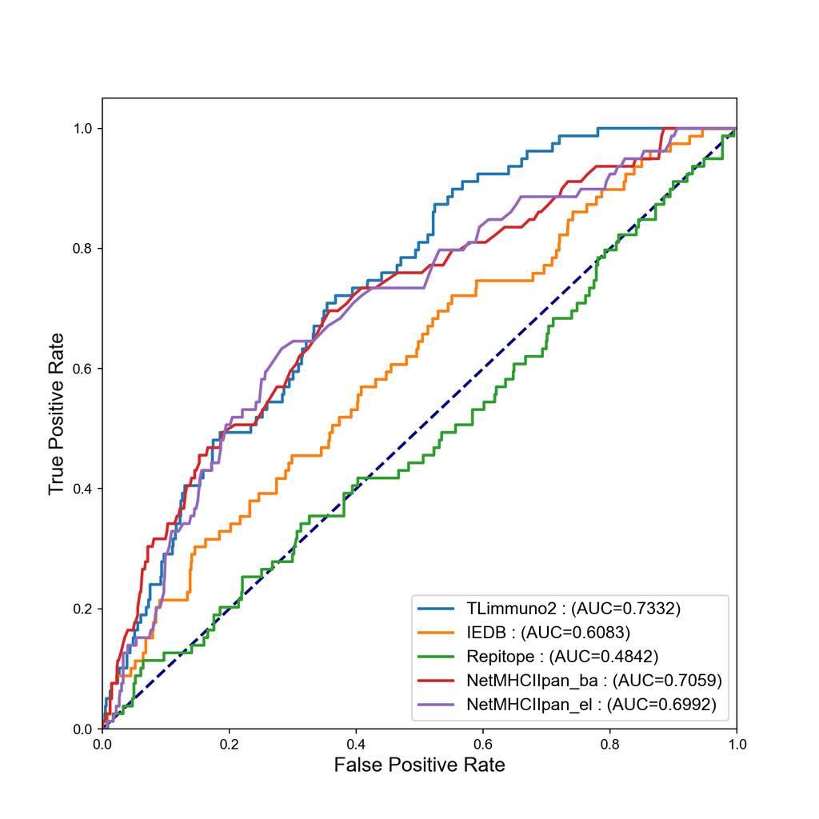

```python
#python
fig,ax = plt.subplots(figsize = (8,8))
lw = 2
ax.plot([0, 1], [0, 1], color='navy', lw=lw, linestyle='--')
ax.plot(mer15_result[0],mer15_result[1],label='TLimmuno2 : (AUC={0:.4f})'.format(mer15_result[4]), lw=lw)
ax.plot(IEDB_score[0],IEDB_score[1],label='IEDB : (AUC={0:.4f})'.format(IEDB_score[4]), lw=lw)
ax.plot(Repitope_score[0],Repitope_score[1],label='Repitope : (AUC={0:.4f})'.format(Repitope_score[4]), lw=lw)
ax.plot(mer15_ba_result[0],mer15_ba_result[1],label='NetMHCIIpan_ba : (AUC={0:.4f})'.format(mer15_ba_result[4]), lw=lw)
ax.plot(mer15_el_result[0],mer15_el_result[1],label='NetMHCIIpan_el : (AUC={0:.4f})'.format(mer15_el_result[4]), lw=lw)
ax.set_ylim([0,1.05])
#> (0.0, 1.05)
ax.set_xlim([0,1])
#> (0.0, 1.0)
ax.set_xlabel('False Positive Rate',fontsize = 14)
ax.set_ylabel('True Positive Rate',fontsize = 14)
ax.legend(loc="lower right",fontsize = 12)
plt.savefig("../figure/benchmark_15mer.pdf",dpi = 300,transparent=True)
plt.show()
```

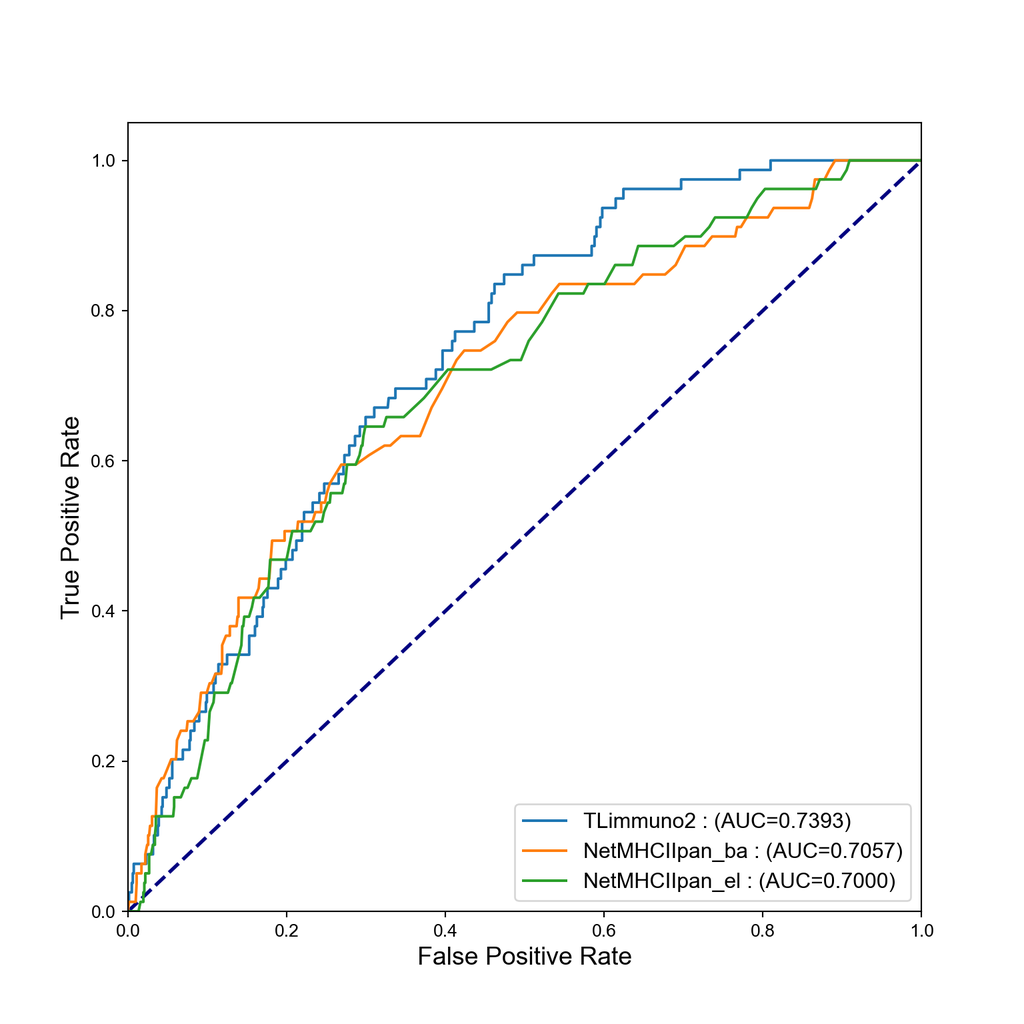

```python
#python
fig,ax = plt.subplots(figsize = (8,8))
lw = 2
ax.plot([0, 1], [0, 1], color='navy', lw=lw, linestyle='--')
ax.plot(kmer_result[0],kmer_result[1],label='TLimmuno2 : (AUC={0:.4f})'.format(kmer_result[4]))
ax.plot(kmer_ba_result[0],kmer_ba_result[1],label='NetMHCIIpan_ba : (AUC={0:.4f})'.format(kmer_ba_result[4]))
ax.plot(kmer_el_result[0],kmer_el_result[1],label='NetMHCIIpan_el : (AUC={0:.4f})'.format(kmer_el_result[4]))
ax.set_ylim([0,1.05])
#> (0.0, 1.05)
ax.set_xlim([0,1])
#> (0.0, 1.0)
ax.set_xlabel('False Positive Rate',fontsize = 14)
ax.set_ylabel('True Positive Rate',fontsize = 14)
ax.legend(loc="lower right",fontsize = 12)
plt.savefig("../figure/benchmark_kmer.pdf",dpi = 300,transparent=True)
plt.show()
```

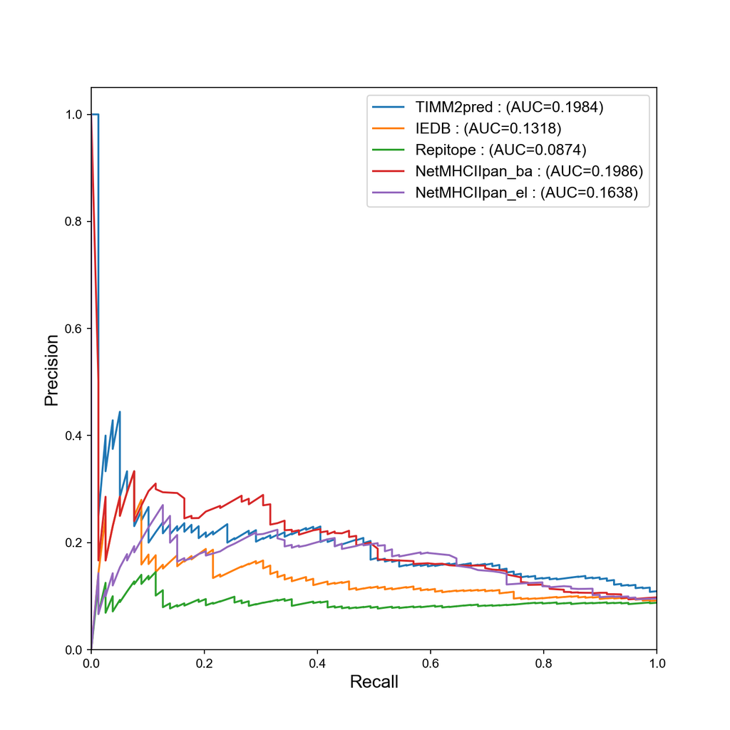

```python
#python
fig,ax = plt.subplots(figsize = (8,8))
lw = 2
ax.plot(mer15_result[2],mer15_result[3],label='TIMM2pred : (AUC={0:.4f})'.format(mer15_result[5]))
ax.plot(IEDB_score[2],IEDB_score[3],label='IEDB : (AUC={0:.4f})'.format(IEDB_score[5]))
ax.plot(Repitope_score[2],Repitope_score[3],label='Repitope : (AUC={0:.4f})'.format(Repitope_score[5]))
ax.plot(mer15_ba_result[2],mer15_ba_result[3],label='NetMHCIIpan_ba : (AUC={0:.4f})'.format(mer15_ba_result[5]))
ax.plot(mer15_el_result[2],mer15_el_result[3],label='NetMHCIIpan_el : (AUC={0:.4f})'.format(mer15_el_result[5]))

plt.xlim([0.0, 1.0])
#> (0.0, 1.0)
plt.ylim([0.0, 1.05])
#> (0.0, 1.05)
plt.xlabel('Recall',fontsize = 14)
plt.ylabel('Precision',fontsize = 14)
plt.legend(loc="upper right",fontsize = 12)
plt.savefig("../figure/15mer_PR.pdf",dpi = 300,transparent=True)
plt.show()
```

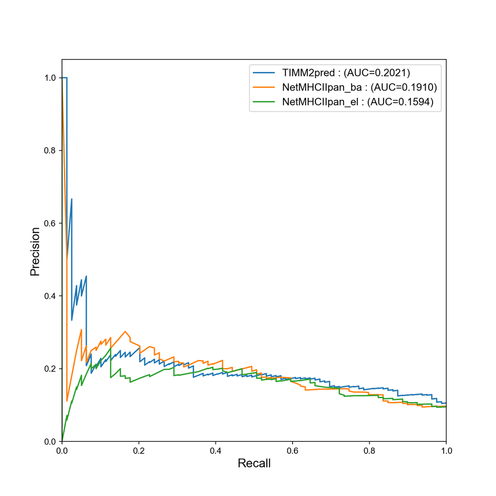

```python
#python
fig,ax = plt.subplots(figsize = (8,8))
lw = 2
ax.plot(kmer_result[2],kmer_result[3],label='TIMM2pred : (AUC={0:.4f})'.format(kmer_result[5]))
ax.plot(kmer_ba_result[2],kmer_ba_result[3],label='NetMHCIIpan_ba : (AUC={0:.4f})'.format(kmer_ba_result[5]))
ax.plot(kmer_el_result[2],kmer_el_result[3],label='NetMHCIIpan_el : (AUC={0:.4f})'.format(kmer_el_result[5]))
plt.xlim([0.0, 1.0])
#> (0.0, 1.0)
plt.ylim([0.0, 1.05])
#> (0.0, 1.05)
plt.xlabel('Recall',fontsize = 14)
plt.ylabel('Precision',fontsize = 14)
plt.legend(loc="upper right",fontsize = 12)
plt.savefig("../figure/kmer_pr.pdf",dpi = 300,transparent=True)
plt.show()
```

### Confusion matrix

```python
result_15mer["pre_label"] = result_15mer["prediction"].map(lambda x : 1 if x>0.5 else 0)
result_15mer_CM = confusion_matrix(result_15mer["Immunogenicity"],result_15mer["pre_label"])
result_15mer_CM = result_15mer_CM/len(result_15mer)
result_kmer["pre_label"] = result_kmer["prediction"].map(lambda x : 1 if x>0.5 else 0)
result_kmer_CM = confusion_matrix(result_kmer["Immunogenicity"],result_kmer["pre_label"])
result_kmer_CM = result_kmer_CM/len(result_kmer)
IEDB_result["pre_label"] = IEDB_result["score"].map(lambda x : 1 if x>50 else 0)
IEDB_result_CM = confusion_matrix(IEDB_result["Immunogenicity"],IEDB_result["pre_label"])
IEDB_result_CM = IEDB_result_CM/len(IEDB_result)
Repitope_result["pre_label"] = Repitope_result["ImmunogenicityScore"].map(lambda x : 1 if x>0.5 else 0)
Repitope_result_CM = confusion_matrix(Repitope_result["Immunogenicity"],Repitope_result["pre_label"])
Repitope_result_CM = Repitope_result_CM/len(Repitope_result)

def net_CM(data):
  data["pre_label"] = data["prediction"].map(lambda x : 1 if x<10 else 0)
  data_CM = confusion_matrix(data["Immunogenicity"],data["pre_label"])
  data_CM = data_CM/len(data)
  return data_CM


net_15mer_ba_CM = net_CM(net_15mer_ba)
net_15mer_el_CM = net_CM(net_15mer_el)
net_kmer_ba_CM = net_CM(net_kmer_ba)
net_kmer_el_CM = net_CM(net_kmer_el)
CM_all = [result_15mer_CM,result_kmer_CM,IEDB_result_CM,Repitope_result_CM,net_15mer_ba_CM,net_15mer_el_CM,net_kmer_ba_CM,net_kmer_el_CM]
```

```python
CM_all = [result_15mer_CM,IEDB_result_CM,Repitope_result_CM,net_15mer_ba_CM,net_15mer_el_CM,result_kmer_CM,net_kmer_ba_CM,net_kmer_el_CM]
CM_label = ["TLimmuno2_15mer","IEDB","Repitope","NetMHCIIpanBA_15mer","NetMHCIIpanEL_15mer","TLimmuon2_kmer","NetMHCIIpanBA_kmer","NetMHCIIpanEL_kmer"]
def CM_plot(data,label):
  fig,ax = plt.subplots(figsize = (4,4))
  sns.heatmap(data,annot =True,cmap="YlGnBu",vmin=0, vmax=1,cbar = False)
  plt.ylabel("True label")
  plt.xlabel("Prediction label")
  plt.title("{}".format(label))

  plt.savefig("../figure/{}.pdf".format(label),dpi = 300,transparent=True)

for i,l in enumerate(CM_all):
  CM_plot(l,CM_label[i])
```

## Structure immportance

Similarly, we want to demonstrate the impact of transfer learning on TLimmuno2, so we reconstructed two models, only BA and without BA. For the only BA model, its input layer contains only the transfer output of the BA model, while for the without BA, we masked the BA model and only the LSTM layer left. The detail code of this part is not inclued in the report. In independent validation datasets, the performance of these two models is significant decreased compared with TLimmuno2. These results demonstrated that the transfer learning approach improves the predictive power of TLimmuno2 in peptide-MHC II immunogenicity prediction.

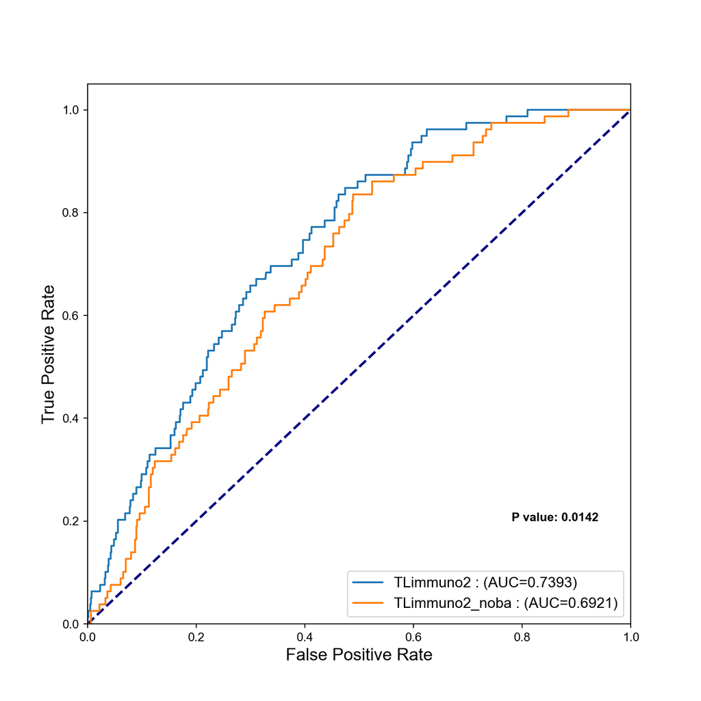

```python
kmer_no_ba = pd.read_csv("/Users/wangguangshuai/Data/MHCII/Data/IMM_model_benchmark/kmer_no_ba_result.csv")
sam_pep_ID = kmer_no_ba["pep_ID"].unique()
sam_pep_ID = kmer_no_ba["pep_ID"].unique()
res = []
p_ID = []
for a in sam_pep_ID:
    Mean = []
    ID = kmer_no_ba[kmer_no_ba["pep_ID"] == a]
    for i in ID["HLA"].unique():
        x = ID[ID["HLA"] == i]
        #x_mean = x["Rank"].mean()
        x_mean = x["prediction"].max()
        Mean.append(x_mean)
    res.append(max(Mean))
    p_ID.append(a)
dic = {"pep_ID":p_ID,"prediction":res}
kmer_no_ba_result = pd.DataFrame(dic)
kmer_no_ba_result = kmer_no_ba_result.merge(peptide,how = "inner",on = "pep_ID" )
kmer_no_ba = auc_pr(kmer_no_ba_result,"Immunogenicity","prediction")
print("AUC:{}".format(kmer_no_ba[4]))
#> AUC:0.6920828538550057
print("PR_AUC:{}".format(kmer_no_ba[5]))
#> PR_AUC:0.14357445791350346
kmer_only_ba = pd.read_csv("/Users/wangguangshuai/Data/MHCII/Data/IMM_model_benchmark/kmer_onlyBA_result.csv")
sam_pep_ID = kmer_only_ba["pep_ID"].unique()
res = []
p_ID = []
for a in sam_pep_ID:
    Mean = []
    ID = kmer_only_ba[kmer_only_ba["pep_ID"] == a]
    for i in ID["HLA"].unique():
        x = ID[ID["HLA"] == i]
        #x_mean = x["Rank"].mean()
        x_mean = x["prediction"].max()
        Mean.append(x_mean)
    res.append(max(Mean))
    p_ID.append(a)
dic = {"pep_ID":p_ID,"prediction":res}
kmer_only_ba_result = pd.DataFrame(dic)
kmer_only_ba_result = kmer_only_ba_result.merge(peptide,how = "inner",on = "pep_ID" )
kmer_only_ba = auc_pr(kmer_only_ba_result,"Immunogenicity","prediction")
print("AUC:{}".format(kmer_only_ba[4]))
#> AUC:0.6529267357115459
print("PR_AUC:{}".format(kmer_only_ba[5]))
#> PR_AUC:0.13744676908175116
z_score_noba,p_val_noba = DelongTest(result_kmer["prediction"],kmer_no_ba_result["prediction"],result_kmer["Immunogenicity"]).show_result()
z_score_only_ba,p_val_only_ba = DelongTest(result_kmer["prediction"],kmer_only_ba_result["prediction"],result_kmer["Immunogenicity"]).show_result()
fig,ax = plt.subplots(figsize = (8,8))
lw = 2
ax.plot([0, 1], [0, 1], color='navy', lw=lw, linestyle='--')
ax.plot(kmer_result[0],kmer_result[1],label='TLimmuno2 : (AUC={0:.4f})'.format(kmer_result[4]))
ax.plot(kmer_no_ba[0],kmer_no_ba[1],label='TLimmuno2_noba : (AUC={0:.4f})'.format(kmer_no_ba[4]))
ax.set_ylim([0,1.05])
#> (0.0, 1.05)
ax.set_xlim([0,1])
#> (0.0, 1.0)
ax.set_xlabel('False Positive Rate',fontsize = 14)
ax.set_ylabel('True Positive Rate',fontsize = 14)
ax.text(0.78,0.2,"P value: {:.4f}".format(p_val_noba),weight="bold")
ax.legend(loc="lower right",fontsize = 12)
plt.savefig("../figure/kmer_noba.pdf",dpi = 300,transparent=True)
plt.show()
```

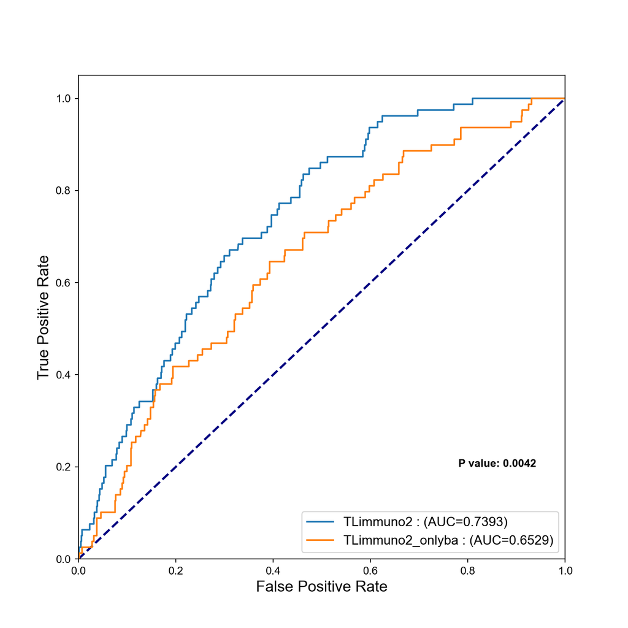

```python
fig,ax = plt.subplots(figsize = (8,8))
lw = 2
ax.plot([0, 1], [0, 1], color='navy', lw=lw, linestyle='--')
ax.plot(kmer_result[0],kmer_result[1],label='TLimmuno2 : (AUC={0:.4f})'.format(kmer_result[4]))
ax.plot(kmer_only_ba[0],kmer_only_ba[1],label='TLimmuno2_onlyba : (AUC={0:.4f})'.format(kmer_only_ba[4]))
ax.set_ylim([0,1.05])
#> (0.0, 1.05)
ax.set_xlim([0,1])
#> (0.0, 1.0)
ax.set_xlabel('False Positive Rate',fontsize = 14)
ax.set_ylabel('True Positive Rate',fontsize = 14)
ax.text(0.78,0.2,"P value: {:.4f}".format(p_val_only_ba),weight="bold")
ax.legend(loc="lower right",fontsize = 12)
plt.savefig("../figure/kmer_onlyba.pdf",dpi = 300,transparent=True)
plt.show()
```

## Neoepitope and wildtype peptide

To further demonstrate the discriminative power of TLimmuno2, we collected 52 MHC II neoepitopes and their corresponding wild-type peptides from published papers . These neoepitopes have been experimentally shown to elicit T cell responses. For each neoantigen and its corresponding wild-type peptide, we predicted the immunogenicity rank values by TLimmuno2. As shown in Figure below, the TLimmuno2 predicted immunogenicity rank values of mutant neopeptides are significantly lower than those of wild-type peptides, and this demonstrates the strong ability of TLimmuno2 in recognizing real neoepitope, even if the neoepitope differs from its wild-type peptide by only one amino acid.

```python
#python
neoantigen = pd.read_csv("../data/neoantigen.csv")
pseudo = pd.read_table("../data/pseudosequence.2016.all.X.dat",header = None,names = ["allele","sequence"])
neoantigen_process = pd.merge(neoantigen,pseudo,left_on = "HLA",right_on = "allele").dropna()
neoantigen_process.to_csv("../data/neoantigen_pro.csv")
```

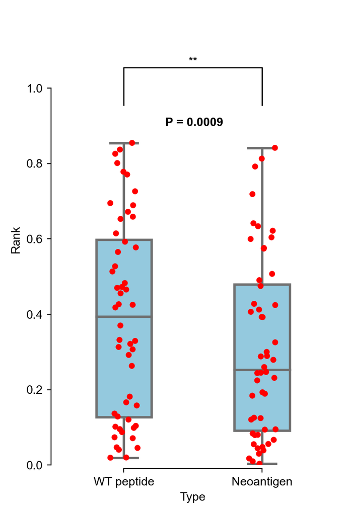

```python
#python

result = pd.read_csv("../data/neoantigen_result.csv")
result = result[result["immunogenic"] == 1]
Rank = pd.melt(result[["WT_Rank","Mut_Rank"]],var_name = "Type",value_name = "Rank")
from scipy import stats
_,p = stats.wilcoxon(result["WT_Rank"],result["Mut_Rank"])
fig,ax = plt.subplots(figsize = (4,6))
ax = sns.boxplot(data = Rank,x = "Type",y = "Rank",width = 0.4,color = "skyblue",linewidth = 2,showfliers = False)
b = sns.stripplot(data = Rank,x = "Type",y = "Rank",color = "red")
x1, x2 = 0, 1
y, h, col = Rank['Rank'].max() + 0.1, 0.1, 'k'
plt.plot([x1, x1, x2, x2], [y, y+h, y+h, y], lw=1, c=col)
#> [<matplotlib.lines.Line2D object at 0x280a895b0>]
plt.text((x1+x2)*.5, y+h, "**", ha='center', va='bottom', color=col)
#> Text(0.5, 1.0549238341796203, '**')
ax.text(0.3,0.9,"P = {:.4f}".format(p),weight="bold")
#> Text(0.3, 0.9, 'P = 0.0009')
plt.ylim([0,1.2])
#> (0.0, 1.2)
plt.yticks(np.arange(0,1.2,0.2))
#> ([<matplotlib.axis.YTick object at 0x17fd02be0>, <matplotlib.axis.YTick object at 0x17fd026a0>, <matplotlib.axis.YTick object at 0x17ffc7460>, <matplotlib.axis.YTick object at 0x17fecc8b0>, <matplotlib.axis.YTick object at 0x17fed7f40>, <matplotlib.axis.YTick object at 0x17fdeb250>], [Text(0, 0, ''), Text(0, 0, ''), Text(0, 0, ''), Text(0, 0, ''), Text(0, 0, ''), Text(0, 0, '')])
plt.xticks((0,1),labels = ["WT peptide","Neoantigen"])
#> ([<matplotlib.axis.XTick object at 0x17fc5d130>, <matplotlib.axis.XTick object at 0x17ffc7b20>], [Text(0, 0, 'WT peptide'), Text(1, 0, 'Neoantigen')])
plt.tight_layout()
sns.despine(offset = 3, trim = True)
plt.savefig("../figure/neoantigen.pdf",dpi = 300,transparent=True)
plt.show()
```

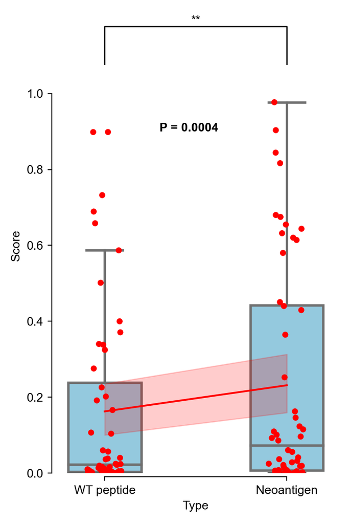

```python
#python
result = pd.read_csv("../data/neoantigen_result.csv")
result = result[result["immunogenic"] == 1]
Rank = pd.melt(result[["WT_prediction","Mut_prediction"]],var_name = "Type",value_name = "Score")
from scipy import stats
_,p = stats.wilcoxon(result["WT_prediction"],result["Mut_prediction"])
fig,ax = plt.subplots(figsize = (4,6))
ax = sns.boxplot(data = Rank,x = "Type",y = "Score",width = 0.4,color = "skyblue",linewidth = 2,showfliers = False)
b = sns.stripplot(data = Rank,x = "Type",y = "Score",color = "red")
sns.lineplot(data = Rank,x = "Type",y = "Score",color = "red")
#> <AxesSubplot:xlabel='Type', ylabel='Score'>
x1, x2 = 0, 1
y, h, col = Rank['Score'].max() + 0.1, 0.1, 'k'
plt.plot([x1, x1, x2, x2], [y, y+h, y+h, y], lw=1, c=col)
#> [<matplotlib.lines.Line2D object at 0x2809163d0>]
plt.text((x1+x2)*.5, y+h, "**", ha='center', va='bottom', color=col)
#> Text(0.5, 1.17707355, '**')
ax.text(0.3,0.9,"P = {:.4f}".format(p),weight="bold")
#> Text(0.3, 0.9, 'P = 0.0004')
plt.ylim([0,1.2])
#> (0.0, 1.2)
plt.yticks(np.arange(0,1.2,0.2))
#> ([<matplotlib.axis.YTick object at 0x28da43700>, <matplotlib.axis.YTick object at 0x28da43520>, <matplotlib.axis.YTick object at 0x2809ba820>, <matplotlib.axis.YTick object at 0x17fd02a60>, <matplotlib.axis.YTick object at 0x28f0c58b0>, <matplotlib.axis.YTick object at 0x28f0c5670>], [Text(0, 0, ''), Text(0, 0, ''), Text(0, 0, ''), Text(0, 0, ''), Text(0, 0, ''), Text(0, 0, '')])
plt.xticks((0,1),labels = ["WT peptide","Neoantigen"])
#> ([<matplotlib.axis.XTick object at 0x2809baeb0>, <matplotlib.axis.XTick object at 0x2809ba4f0>], [Text(0, 0, 'WT peptide'), Text(1, 0, 'Neoantigen')])
plt.tight_layout()
sns.despine(offset = 3, trim = True)
#plt.savefig("../figure/neoantigen_prediction.pdf",dpi = 300,transparent=True)
plt.show()
```

## Position importance

### TLimmuno2

We performed in silico mutational analyses to investigate whether TLimmuno2 was able to learn the molecular characteristics of the peptide. By changing the amino acid residues at each position, we compare the differences of the predicted values, and the largest decrease corresponds to the greater importance of the position. We do this in two methods: ala-scanning and zero-setting. For ala-scanning, we sequentially replaced each position as the alanine; for zero-setting, we sequentially mutated each position (the representation vector for the mutated position is all zeros). We simulated this process 100 times and an ascending ranking was performed each time to highlight the most salient positions.

```python
#python
#PBS
import pandas as pd
import tensorflow as tf
import sys
sys.path.append("/public/slst/home/wanggsh/Project/MHCII/utils")
from Blosum62 import blosum62
import numpy as np
import random
import matplotlib.pyplot as plt
import matplotlib as mpl
import os
#os.environ["CUDA_VISIBLE_DEVICES"]="-1"

immuno_data = pd.read_csv("/public/slst/home/wanggsh/Data/MHCII_immuno/IMM_data_random2.csv")
immuno_data = immuno_data[immuno_data["label"] == 1]
immuno_data["length"] = immuno_data["Description"].map(len)
#choose 15mer
immuno_data = immuno_data[immuno_data["length"] == 15]
immuno_data = immuno_data.reset_index(drop=True)

immuno_data["pep_blosum"] = immuno_data["Description"].apply(blosum62,args=(21,))
immuno_data["MHC_blosum"] = immuno_data["sequence"].apply(blosum62,args=(34,))
peptide = np.empty((len(immuno_data),21,21))
for i in range(len(immuno_data)):
    peptide[i] = immuno_data["pep_blosum"][i].reshape((21,21))
#mhc
MHC = np.empty((len(immuno_data),34,21))
for i in range(len(immuno_data)):
    MHC[i] = immuno_data["MHC_blosum"][i].reshape((34,21))
Ala = list(blosum62("A",1))

BAmodel = tf.keras.models.load_model("/public/slst/home/wanggsh/Project/Saved_model/new_BA_model/model1")
BAmodel = tf.keras.models.Model(inputs = BAmodel.input,outputs = BAmodel.layers[-2].output)
IMM = tf.keras.models.load_model("/public/slst/home/wanggsh/Project/Saved_model/MHCII_immuno/model")

n = 100
position_rank = np.empty([n,15])
for m in range(n):
    index = np.random.choice(np.arange(len(immuno_data)),2000)
    peptide_sam = peptide[index].copy()
    MHC_sam = MHC[index]
    BA = BAmodel.predict([peptide_sam,MHC_sam])
    pred_ori = IMM([peptide_sam,MHC_sam,BA]).numpy().mean()
    array = []
    for i in range(15):
        peptide_sam[:,i,:] = 0
        BA = BAmodel.predict([peptide_sam,MHC_sam])
        importance = pred_ori - IMM([peptide_sam,MHC_sam,BA]).numpy().mean()
        array.append(importance)
        peptide_sam = peptide[index].copy()
    ranking = np.argsort(array) + 1
    tmp = []
    for i in range(15):
        tmp.append(list(ranking).index(i+1))
    position_rank[m,:] = tmp
np.save("/public/slst/home/wanggsh/Data/MHCII_immuno/position_importance/position.npy",position_rank)

n = 100
position_rank_ala = np.empty([n,15])
for m in range(n):
    index = np.random.choice(np.arange(len(immuno_data)),2000)
    peptide_sam = peptide[index].copy()
    MHC_sam = MHC[index]
    BA = BAmodel.predict([peptide_sam,MHC_sam])
    pred_ori = IMM([peptide_sam,MHC_sam,BA]).numpy().mean()
    array = []
    for i in range(15):
        peptide_sam[:,i,:] = Ala
        BA = BAmodel.predict([peptide_sam,MHC_sam])
        importance = pred_ori - IMM([peptide_sam,MHC_sam,BA]).numpy().mean()
        array.append(importance)
        peptide_sam = peptide[index].copy()
    ranking = np.argsort(array) + 1
    tmp = []
    for i in range(15):
        tmp.append(list(ranking).index(i+1))
    position_rank[m,:] = tmp
np.save("/public/slst/home/wanggsh/Data/MHCII_immuno/position_importance/position_ala.npy",position_rank)
```

#### plt figure

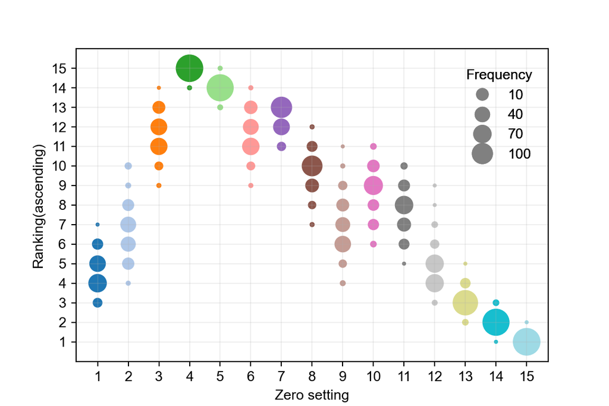

```python
#python
from collections import Counter
position_rank = np.load("../data/position.npy")
cmap = mpl.cm.get_cmap('tab20')
delim = np.linspace(0,1,15)
colors = [mpl.colors.rgb2hex(cmap(i)[:4]) for i in delim]
fig,ax = plt.subplots(figsize = (6,4))
for i in np.arange(15):
    y = list(Counter(position_rank[:,i]+1).keys())
    s = list(Counter(position_rank[:,i]+1).values())
    ax.scatter([i for n in range(len(y))],y, s=[m*3.5 for m in s],c=colors[i])
#> <matplotlib.collections.PathCollection object at 0x17fd15250>
#> <matplotlib.collections.PathCollection object at 0x17fd15b20>
#> <matplotlib.collections.PathCollection object at 0x17fd15820>
#> <matplotlib.collections.PathCollection object at 0x17fd15eb0>
#> <matplotlib.collections.PathCollection object at 0x28f0c66a0>
#> <matplotlib.collections.PathCollection object at 0x28f0c69a0>
#> <matplotlib.collections.PathCollection object at 0x28f0c6670>
#> <matplotlib.collections.PathCollection object at 0x17fd00fd0>
#> <matplotlib.collections.PathCollection object at 0x28f0c61f0>
#> <matplotlib.collections.PathCollection object at 0x17fc87fd0>
#> <matplotlib.collections.PathCollection object at 0x17fe68580>
#> <matplotlib.collections.PathCollection object at 0x17fc87940>
#> <matplotlib.collections.PathCollection object at 0x17fe68e80>
#> <matplotlib.collections.PathCollection object at 0x17fe3a370>
#> <matplotlib.collections.PathCollection object at 0x17fe68910>
ax.set_ylim(0,16)
#> (0.0, 16.0)
ax.set_yticks(np.arange(15)+1)
#> [<matplotlib.axis.YTick object at 0x28f093be0>, <matplotlib.axis.YTick object at 0x1754f3e20>, <matplotlib.axis.YTick object at 0x17fc87670>, <matplotlib.axis.YTick object at 0x17fe3ae80>, <matplotlib.axis.YTick object at 0x17fe35610>, <matplotlib.axis.YTick object at 0x17fe35d60>, <matplotlib.axis.YTick object at 0x17fe644f0>, <matplotlib.axis.YTick object at 0x17fe35d90>, <matplotlib.axis.YTick object at 0x17fe3a9d0>, <matplotlib.axis.YTick object at 0x17fe64df0>, <matplotlib.axis.YTick object at 0x17fe58580>, <matplotlib.axis.YTick object at 0x17fe58cd0>, <matplotlib.axis.YTick object at 0x17fe39460>, <matplotlib.axis.YTick object at 0x17fe39bb0>, <matplotlib.axis.YTick object at 0x17fe39730>]
ax.set_xticks(np.arange(15))
#> [<matplotlib.axis.XTick object at 0x17fe6eb20>, <matplotlib.axis.XTick object at 0x17fc87760>, <matplotlib.axis.XTick object at 0x28da106d0>, <matplotlib.axis.XTick object at 0x17fe5b220>, <matplotlib.axis.XTick object at 0x17fe5b8b0>, <matplotlib.axis.XTick object at 0x28096a040>, <matplotlib.axis.XTick object at 0x28096a790>, <matplotlib.axis.XTick object at 0x28095f040>, <matplotlib.axis.XTick object at 0x28096aa30>, <matplotlib.axis.XTick object at 0x17fe5b640>, <matplotlib.axis.XTick object at 0x28095f430>, <matplotlib.axis.XTick object at 0x28095fa60>, <matplotlib.axis.XTick object at 0x2809421f0>, <matplotlib.axis.XTick object at 0x280942940>, <matplotlib.axis.XTick object at 0x2809500d0>]
ax.set_xticklabels(['1','2','3','4','5','6','7','8','9','10','11','12','13','14','15'])
#> [Text(0, 0, '1'), Text(1, 0, '2'), Text(2, 0, '3'), Text(3, 0, '4'), Text(4, 0, '5'), Text(5, 0, '6'), Text(6, 0, '7'), Text(7, 0, '8'), Text(8, 0, '9'), Text(9, 0, '10'), Text(10, 0, '11'), Text(11, 0, '12'), Text(12, 0, '13'), Text(13, 0, '14'), Text(14, 0, '15')]
ax.set_xlabel('Zero setting')
#> Text(0.5, 0, 'Zero setting')
ax.set_ylabel('Ranking(ascending)')
#> Text(0, 0.5, 'Ranking(ascending)')
ax.grid(True,alpha=0.2)
h1 = [ax.plot([],[],color='grey',marker='o',markersize=i,ls='')[0] for i in range(8,15,2)]
leg1 = ax.legend(handles=h1,labels=[10,40,70,100],title='Frequency',loc='lower left',bbox_to_anchor=(0.8,0.6),frameon=False)
ax.add_artist(leg1)
#> <matplotlib.legend.Legend object at 0x17fe3aee0>
plt.savefig("../figure/position_zero.pdf",dpi = 300,transparent=True)
plt.show()
```

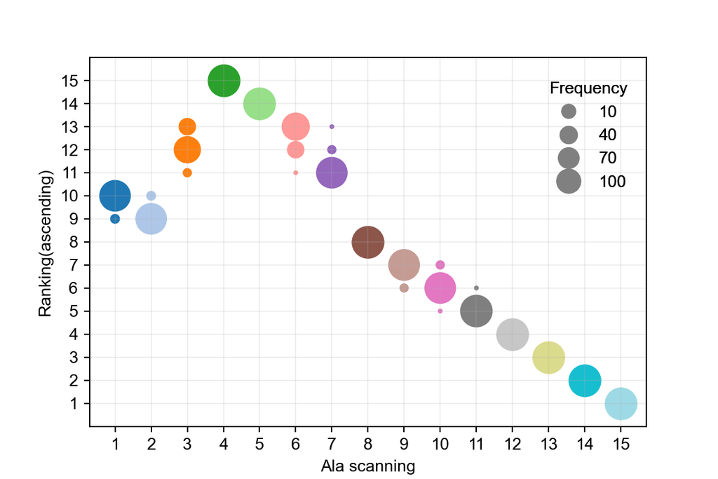

```python
#python
position_rank_ala = np.load("../data/position_ala.npy")
cmap = mpl.cm.get_cmap('tab20')
delim = np.linspace(0,1,15)
colors = [mpl.colors.rgb2hex(cmap(i)[:4]) for i in delim]
fig,ax = plt.subplots(figsize = (6,4))
for i in np.arange(15):
    y = list(Counter(position_rank_ala[:,i]+1).keys())
    s = list(Counter(position_rank_ala[:,i]+1).values())
    ax.scatter([i for n in range(len(y))],y, s=[m*3.5 for m in s],c=colors[i])
#> <matplotlib.collections.PathCollection object at 0x17fcdcdc0>
#> <matplotlib.collections.PathCollection object at 0x17fcdc730>
#> <matplotlib.collections.PathCollection object at 0x2809a4b80>
#> <matplotlib.collections.PathCollection object at 0x17fcdc550>
#> <matplotlib.collections.PathCollection object at 0x2809a4a90>
#> <matplotlib.collections.PathCollection object at 0x17fd9fdc0>
#> <matplotlib.collections.PathCollection object at 0x28099ba60>
#> <matplotlib.collections.PathCollection object at 0x28099b1c0>
#> <matplotlib.collections.PathCollection object at 0x17fc44730>
#> <matplotlib.collections.PathCollection object at 0x17fe6e4f0>
#> <matplotlib.collections.PathCollection object at 0x17ff1ebe0>
#> <matplotlib.collections.PathCollection object at 0x2809a7f40>
#> <matplotlib.collections.PathCollection object at 0x17ff36250>
#> <matplotlib.collections.PathCollection object at 0x17ff36100>
#> <matplotlib.collections.PathCollection object at 0x17fded610>
ax.set_ylim(0,16)
#> (0.0, 16.0)
ax.set_yticks(np.arange(15)+1)
#> [<matplotlib.axis.YTick object at 0x17fe10490>, <matplotlib.axis.YTick object at 0x17fe104f0>, <matplotlib.axis.YTick object at 0x2809444f0>, <matplotlib.axis.YTick object at 0x17fdedb50>, <matplotlib.axis.YTick object at 0x1736a3460>, <matplotlib.axis.YTick object at 0x17fcc1b20>, <matplotlib.axis.YTick object at 0x17ff1d820>, <matplotlib.axis.YTick object at 0x17ffd7970>, <matplotlib.axis.YTick object at 0x17ffd70a0>, <matplotlib.axis.YTick object at 0x17ff393d0>, <matplotlib.axis.YTick object at 0x17ffd7940>, <matplotlib.axis.YTick object at 0x1736a3bb0>, <matplotlib.axis.YTick object at 0x17ff049d0>, <matplotlib.axis.YTick object at 0x17ffdff70>, <matplotlib.axis.YTick object at 0x17fbe4ca0>]
ax.set_xticks(np.arange(15))
#> [<matplotlib.axis.XTick object at 0x17fe10e80>, <matplotlib.axis.XTick object at 0x17fe10e20>, <matplotlib.axis.XTick object at 0x17fd9fc10>, <matplotlib.axis.XTick object at 0x17ffbdf70>, <matplotlib.axis.XTick object at 0x17ff04790>, <matplotlib.axis.XTick object at 0x17ffd7ac0>, <matplotlib.axis.XTick object at 0x2809b3970>, <matplotlib.axis.XTick object at 0x17ffc71f0>, <matplotlib.axis.XTick object at 0x17ffc72b0>, <matplotlib.axis.XTick object at 0x17feca940>, <matplotlib.axis.XTick object at 0x17ffc7be0>, <matplotlib.axis.XTick object at 0x2809ba070>, <matplotlib.axis.XTick object at 0x2809013d0>, <matplotlib.axis.XTick object at 0x280901910>, <matplotlib.axis.XTick object at 0x17fd1c5e0>]
ax.set_xticklabels(['1','2','3','4','5','6','7','8','9','10','11','12','13','14','15'])
#> [Text(0, 0, '1'), Text(1, 0, '2'), Text(2, 0, '3'), Text(3, 0, '4'), Text(4, 0, '5'), Text(5, 0, '6'), Text(6, 0, '7'), Text(7, 0, '8'), Text(8, 0, '9'), Text(9, 0, '10'), Text(10, 0, '11'), Text(11, 0, '12'), Text(12, 0, '13'), Text(13, 0, '14'), Text(14, 0, '15')]
ax.set_xlabel('Ala scanning')
#> Text(0.5, 0, 'Ala scanning')
ax.set_ylabel('Ranking(ascending)')
#> Text(0, 0.5, 'Ranking(ascending)')
ax.grid(True,alpha=0.2)
h1 = [ax.plot([],[],color='grey',marker='o',markersize=i,ls='')[0] for i in range(8,15,2)]
leg1 = ax.legend(handles=h1,labels=[10,40,70,100],title='Frequency',loc='lower left',bbox_to_anchor=(0.8,0.6),frameon=False)
ax.add_artist(leg1)
#> <matplotlib.legend.Legend object at 0x280944370>
plt.savefig("../figure/position_ala.pdf",dpi = 300,transparent=True)
plt.show()
```

Both results show that P4 (residue 4), P5, and P6 are very important for model prediction. This result is consistent with the results related to MHC class I molecules, and it is reported that these positions are essential for interacting with the TCR. But unlike MHC I molecules, MHC II molecules exhibit a tendency to have less effect on model predictions due to its position closer to the tail, possibly due to its open binding cleft. The results of Ala-scanning are more stable rather than zero-setting, because Ala also has biological functions.

### BA model

We also do the same things by using BA model.

```python
import pandas as pd
import tensorflow as tf
import sys
sys.path.append("/public/slst/home/wanggsh/Project/MHCII/utils")
from Blosum62 import blosum62
import numpy as np
import random
import matplotlib.pyplot as plt
import matplotlib as mpl
import os
#os.environ["CUDA_VISIBLE_DEVICES"]="-1"


immuno_data = pd.read_csv("/public/slst/home/wanggsh/Data/MHCII/netMHCpanII4.0_train_data/BA_data/BA_MHC_label.csv")
immuno_data = immuno_data[immuno_data["score"] == 1]
immuno_data["length"] = immuno_data["peptide"].map(len)
#choose 15mer
immuno_data = immuno_data[immuno_data["length"] == 15]
immuno_data = immuno_data.reset_index(drop=True)


immuno_data["pep_blosum"] = immuno_data["peptide"].apply(blosum62,args=(21,))
immuno_data["MHC_blosum"] = immuno_data["sequence"].apply(blosum62,args=(34,))
peptide = np.empty((len(immuno_data),21,21))
for i in range(len(immuno_data)):
    peptide[i] = immuno_data["pep_blosum"][i].reshape((21,21))
#mhc
MHC = np.empty((len(immuno_data),34,21))
for i in range(len(immuno_data)):
    MHC[i] = immuno_data["MHC_blosum"][i].reshape((34,21))
Ala = list(blosum62("A",1))

BAmodel = tf.keras.models.load_model("/public/slst/home/wanggsh/Project/Saved_model/new_BA_model/model1")

n = 100
position_rank = np.empty([n,15])
for m in range(n):
    index = np.random.choice(np.arange(len(immuno_data)),2000)
    peptide_sam = peptide[index].copy()
    MHC_sam = MHC[index]
    pred_ori = BAmodel([peptide_sam,MHC_sam]).numpy().mean()
    array = []
    for i in range(15):
        peptide_sam[:,i,:] = 0
        importance = pred_ori - BAmodel([peptide_sam,MHC_sam]).numpy().mean()
        array.append(importance)
        peptide_sam = peptide[index].copy()
    ranking = np.argsort(array) + 1
    tmp = []
    for i in range(15):
        tmp.append(list(ranking).index(i+1))
    position_rank[m,:] = tmp
np.save("/public/slst/home/wanggsh/Data/MHCII_immuno/position_importance/position_zero_BA.npy",position_rank)

n = 100
position_rank_ala = np.empty([n,15])
for m in range(n):
    index = np.random.choice(np.arange(len(immuno_data)),2000)
    peptide_sam = peptide[index].copy()
    MHC_sam = MHC[index]
    pred_ori = BAmodel([peptide_sam,MHC_sam]).numpy().mean()
    array = []
    for i in range(15):
        peptide_sam[:,i,:] = Ala
        importance = pred_ori - BAmodel([peptide_sam,MHC_sam]).numpy().mean()
        array.append(importance)
        peptide_sam = peptide[index].copy()
    ranking = np.argsort(array) + 1
    tmp = []
    for i in range(15):
        tmp.append(list(ranking).index(i+1))
    position_rank[m,:] = tmp
np.save("/public/slst/home/wanggsh/Data/MHCII_immuno/position_importance/position_ala_BA.npy",position_rank)
```

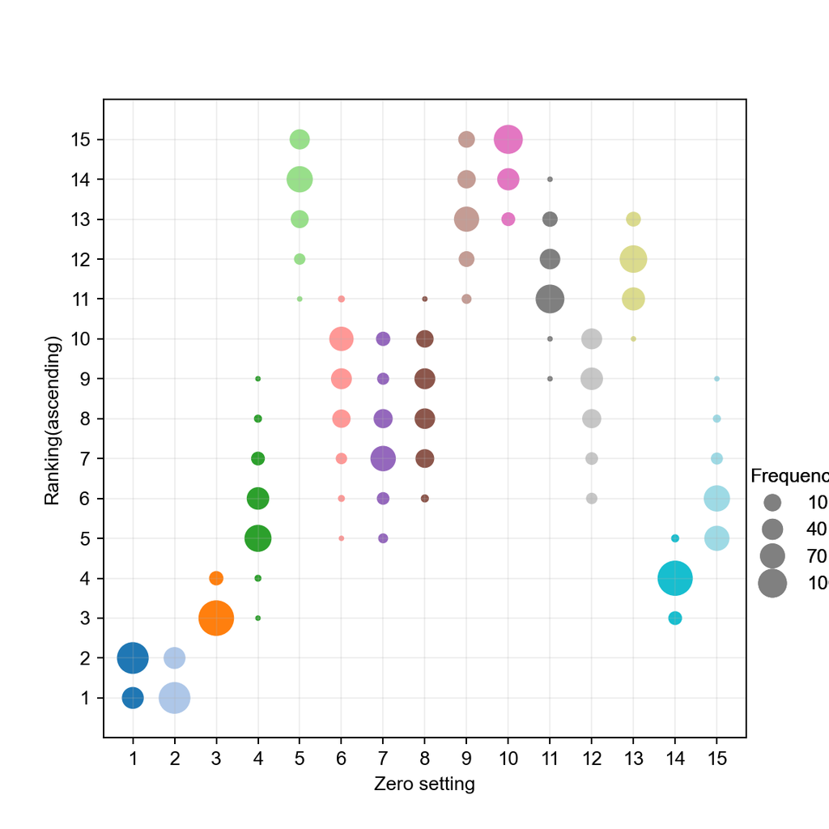

```python
#python
from collections import Counter
position_rank = np.load("../data/position_zero_BA.npy")
cmap = mpl.cm.get_cmap('tab20')
delim = np.linspace(0,1,15)
colors = [mpl.colors.rgb2hex(cmap(i)[:4]) for i in delim]
fig,ax = plt.subplots(figsize = (6,6))
for i in np.arange(15):
    y = list(Counter(position_rank[:,i]+1).keys())
    s = list(Counter(position_rank[:,i]+1).values())
    ax.scatter([i for n in range(len(y))],y, s=[m*3.5 for m in s],c=colors[i])
#> <matplotlib.collections.PathCollection object at 0x17fd02880>
#> <matplotlib.collections.PathCollection object at 0x17ffe2820>
#> <matplotlib.collections.PathCollection object at 0x17fbe0e50>
#> <matplotlib.collections.PathCollection object at 0x17ffb6f40>
#> <matplotlib.collections.PathCollection object at 0x17fe5bbe0>
#> <matplotlib.collections.PathCollection object at 0x17fe5b7f0>
#> <matplotlib.collections.PathCollection object at 0x17fe5b1f0>
#> <matplotlib.collections.PathCollection object at 0x28095f940>
#> <matplotlib.collections.PathCollection object at 0x28095f490>
#> <matplotlib.collections.PathCollection object at 0x17fbe0fa0>
#> <matplotlib.collections.PathCollection object at 0x28096af40>
#> <matplotlib.collections.PathCollection object at 0x28096adf0>
#> <matplotlib.collections.PathCollection object at 0x28096a6a0>
#> <matplotlib.collections.PathCollection object at 0x17fe3adf0>
#> <matplotlib.collections.PathCollection object at 0x17fe3aac0>
ax.set_ylim(0,16)
#> (0.0, 16.0)
ax.set_yticks(np.arange(15)+1)
#> [<matplotlib.axis.YTick object at 0x1736a3ee0>, <matplotlib.axis.YTick object at 0x17148c190>, <matplotlib.axis.YTick object at 0x17ffbdb50>, <matplotlib.axis.YTick object at 0x17fe64eb0>, <matplotlib.axis.YTick object at 0x17fe644f0>, <matplotlib.axis.YTick object at 0x28092f370>, <matplotlib.axis.YTick object at 0x28092fbe0>, <matplotlib.axis.YTick object at 0x28f1ad130>, <matplotlib.axis.YTick object at 0x28f1ada00>, <matplotlib.axis.YTick object at 0x28092f6a0>, <matplotlib.axis.YTick object at 0x28096ab80>, <matplotlib.axis.YTick object at 0x28092ef10>, <matplotlib.axis.YTick object at 0x28092e5b0>, <matplotlib.axis.YTick object at 0x17fe39730>, <matplotlib.axis.YTick object at 0x17fe39d00>]
ax.set_xticks(np.arange(15))
#> [<matplotlib.axis.XTick object at 0x17ffbd400>, <matplotlib.axis.XTick object at 0x17ffbda60>, <matplotlib.axis.XTick object at 0x173823790>, <matplotlib.axis.XTick object at 0x28092e610>, <matplotlib.axis.XTick object at 0x28092f160>, <matplotlib.axis.XTick object at 0x17ff422e0>, <matplotlib.axis.XTick object at 0x17ff42910>, <matplotlib.axis.XTick object at 0x178c17670>, <matplotlib.axis.XTick object at 0x178c17df0>, <matplotlib.axis.XTick object at 0x17ff428e0>, <matplotlib.axis.XTick object at 0x28092eaf0>, <matplotlib.axis.XTick object at 0x178c174c0>, <matplotlib.axis.XTick object at 0x28f1c1e80>, <matplotlib.axis.XTick object at 0x28f1c1ac0>, <matplotlib.axis.XTick object at 0x17fe29250>]
ax.set_xticklabels(['1','2','3','4','5','6','7','8','9','10','11','12','13','14','15'])
#> [Text(0, 0, '1'), Text(1, 0, '2'), Text(2, 0, '3'), Text(3, 0, '4'), Text(4, 0, '5'), Text(5, 0, '6'), Text(6, 0, '7'), Text(7, 0, '8'), Text(8, 0, '9'), Text(9, 0, '10'), Text(10, 0, '11'), Text(11, 0, '12'), Text(12, 0, '13'), Text(13, 0, '14'), Text(14, 0, '15')]
ax.set_xlabel('Zero setting')
#> Text(0.5, 0, 'Zero setting')
ax.set_ylabel('Ranking(ascending)')
#> Text(0, 0.5, 'Ranking(ascending)')
ax.grid(True,alpha=0.2)
h1 = [ax.plot([],[],color='grey',marker='o',markersize=i,ls='')[0] for i in range(8,15,2)]
leg1 = ax.legend(handles=h1,labels=[10,40,70,100],title='Frequency',loc='lower left',bbox_to_anchor=(0.98,0.2),frameon=False)
ax.add_artist(leg1)
#> <matplotlib.legend.Legend object at 0x17fdebd60>
plt.savefig("../figure/position_zero_BA.pdf",dpi = 300,bbox_inches='tight',transparent=True)
plt.show()
```

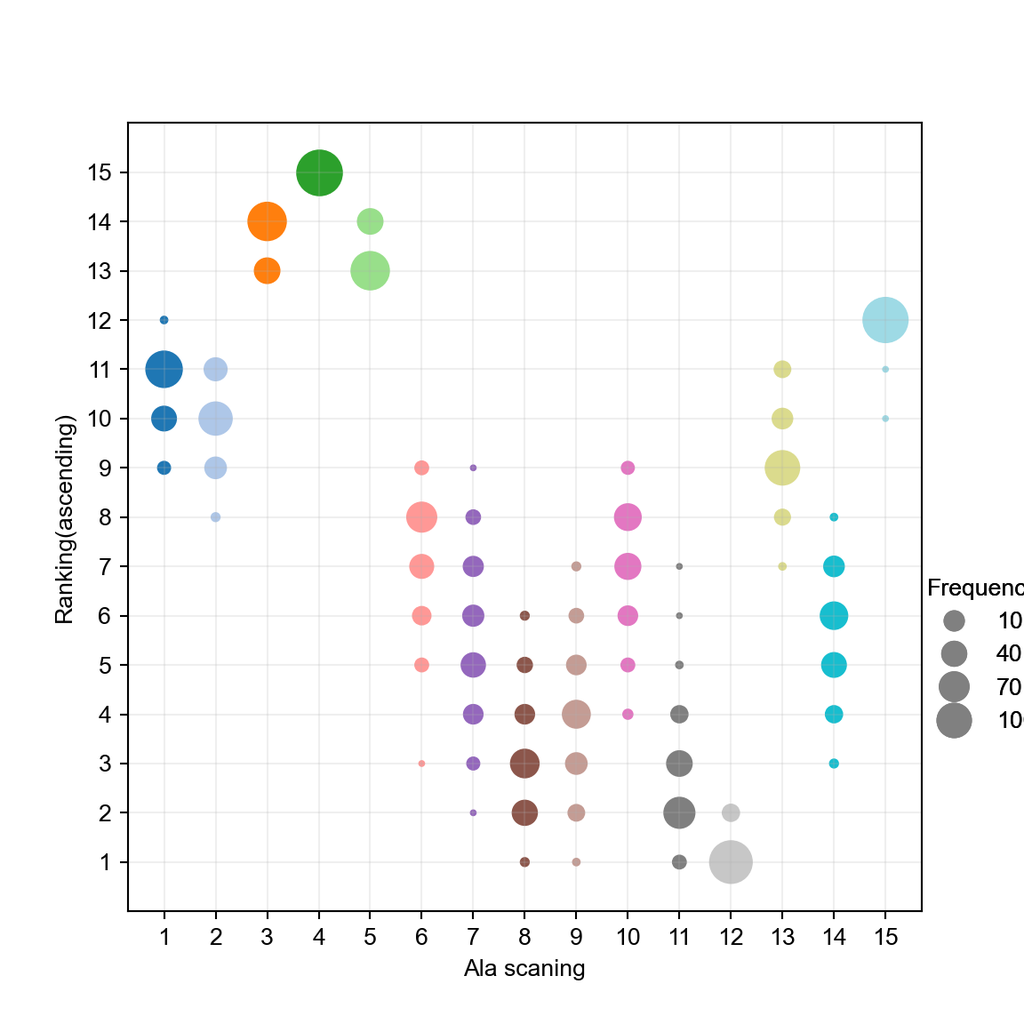

```python
#python
position_rank_ala = np.load("../data/position_ala_BA.npy")
cmap = mpl.cm.get_cmap('tab20')
delim = np.linspace(0,1,15)
colors = [mpl.colors.rgb2hex(cmap(i)[:4]) for i in delim]
fig,ax = plt.subplots(figsize = (6,6))
#> <string>:1: RuntimeWarning: More than 20 figures have been opened. Figures created through the pyplot interface (`matplotlib.pyplot.figure`) are retained until explicitly closed and may consume too much memory. (To control this warning, see the rcParam `figure.max_open_warning`).
for i in np.arange(15):
    y = list(Counter(position_rank_ala[:,i]+1).keys())
    s = list(Counter(position_rank_ala[:,i]+1).values())
    ax.scatter([i for n in range(len(y))],y, s=[m*3.5 for m in s],c=colors[i])
#> <matplotlib.collections.PathCollection object at 0x17ff918b0>
#> <matplotlib.collections.PathCollection object at 0x17ff914c0>
#> <matplotlib.collections.PathCollection object at 0x17ff91340>
#> <matplotlib.collections.PathCollection object at 0x17ffa5310>
#> <matplotlib.collections.PathCollection object at 0x28db33a30>
#> <matplotlib.collections.PathCollection object at 0x28db331f0>
#> <matplotlib.collections.PathCollection object at 0x28db33f40>
#> <matplotlib.collections.PathCollection object at 0x17ffbde50>
#> <matplotlib.collections.PathCollection object at 0x17ffbd8b0>
#> <matplotlib.collections.PathCollection object at 0x280a89be0>
#> <matplotlib.collections.PathCollection object at 0x17ffbdd00>
#> <matplotlib.collections.PathCollection object at 0x17fd1c2e0>
#> <matplotlib.collections.PathCollection object at 0x17fd354c0>
#> <matplotlib.collections.PathCollection object at 0x28099b400>
#> <matplotlib.collections.PathCollection object at 0x17fd35e20>
ax.set_ylim(0,16)
#> (0.0, 16.0)
ax.set_yticks(np.arange(15)+1)
#> [<matplotlib.axis.YTick object at 0x17ff425e0>, <matplotlib.axis.YTick object at 0x17ff42550>, <matplotlib.axis.YTick object at 0x17fecc7c0>, <matplotlib.axis.YTick object at 0x2809a7850>, <matplotlib.axis.YTick object at 0x17ffbc3d0>, <matplotlib.axis.YTick object at 0x17ffc7580>, <matplotlib.axis.YTick object at 0x17ffc7220>, <matplotlib.axis.YTick object at 0x28db3d820>, <matplotlib.axis.YTick object at 0x28db3d580>, <matplotlib.axis.YTick object at 0x17ffd7c70>, <matplotlib.axis.YTick object at 0x28db3d850>, <matplotlib.axis.YTick object at 0x17fbea400>, <matplotlib.axis.YTick object at 0x17ffd7280>, <matplotlib.axis.YTick object at 0x2809b33d0>, <matplotlib.axis.YTick object at 0x17fc86f40>]
ax.set_xticks(np.arange(15))
#> [<matplotlib.axis.XTick object at 0x17feccb50>, <matplotlib.axis.XTick object at 0x17fecc130>, <matplotlib.axis.XTick object at 0x17ffb6400>, <matplotlib.axis.XTick object at 0x17fe10550>, <matplotlib.axis.XTick object at 0x17ffd7d60>, <matplotlib.axis.XTick object at 0x17ffc5b80>, <matplotlib.axis.XTick object at 0x17fcc1d00>, <matplotlib.axis.XTick object at 0x17fd36880>, <matplotlib.axis.XTick object at 0x17ff1ed60>, <matplotlib.axis.XTick object at 0x17ff1e400>, <matplotlib.axis.XTick object at 0x17ff1e7f0>, <matplotlib.axis.XTick object at 0x17ffc5880>, <matplotlib.axis.XTick object at 0x280944640>, <matplotlib.axis.XTick object at 0x280944040>, <matplotlib.axis.XTick object at 0x17fd9feb0>]
ax.set_xticklabels(['1','2','3','4','5','6','7','8','9','10','11','12','13','14','15'])
#> [Text(0, 0, '1'), Text(1, 0, '2'), Text(2, 0, '3'), Text(3, 0, '4'), Text(4, 0, '5'), Text(5, 0, '6'), Text(6, 0, '7'), Text(7, 0, '8'), Text(8, 0, '9'), Text(9, 0, '10'), Text(10, 0, '11'), Text(11, 0, '12'), Text(12, 0, '13'), Text(13, 0, '14'), Text(14, 0, '15')]
ax.set_xlabel('Ala scaning')
#> Text(0.5, 0, 'Ala scaning')
ax.set_ylabel('Ranking(ascending)')
#> Text(0, 0.5, 'Ranking(ascending)')
ax.grid(True,alpha=0.2)
h1 = [ax.plot([],[],color='grey',marker='o',markersize=i,ls='')[0] for i in range(8,15,2)]
leg1 = ax.legend(handles=h1,labels=[10,40,70,100],title='Frequency',loc='lower left',bbox_to_anchor=(0.98,0.2),frameon=False)
ax.add_artist(leg1)
#> <matplotlib.legend.Legend object at 0x1715296a0>
plt.savefig("../figure/position_ala_BA.pdf",dpi = 300,bbox_inches='tight',transparent=True)
plt.show()
```

Furthermore, the BA model does not show the same trend, it is possible that the features learned by the affinity prediction model are the interaction between MHC and peptide compared to the features learned by the immunogenicity prediction model.